# koalas

## Overview

The koalas package is intended to be used for exploring chlamydia control programmes. The package is still being developed, and feedback is welcomed (contact details are available [here](https://ivh.ku.dk/english/employees/?pure=en/persons/487288) and via my private consultancy company [here](http://www.m2d2consultancy.com)).

## Installation

The latest release version of the package can be installed from r-universe:

```r
install.packages(c("koalas","tidyverse"),
  repos=c("https://ku-awdc.r-universe.dev/", "https://cran.rstudio.com/"))
```

This also installs the tidyverse package from CRAN, which is used in this vignette for plotting etc. Note that C++ compilers are NOT required for installation as long as your installed version of R is current. This should cover most use cases.

Alternatively, you can install the development version directly from GitHub. To do that you must first pre-install the remotes package (from CRAN) and the IPDMR package (from ku-awdc.r-universe.dev/):

```r
install.packages(c("IPDMR","remotes"),
  repos=c("https://ku-awdc.r-universe.dev/", "https://cran.rstudio.com/"))
```

Then you can install the koalas package from source:

```r
remotes::install_github("ku-awdc/koalas")
```

Note that this last step requires C++ compilers.

## TLDR; Quick guide to running scenarios

The pre-determined scenarios can be run in the following way:

```r
library("koalas")
model <- KoalasV2$new()
model$burnin()
```

This runs the model from 1st July 2022 up to 1st October 2025, which is where we might start doing active interventions:

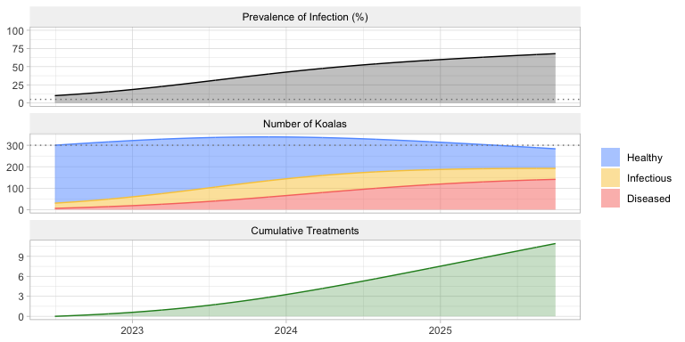

```r
library("ggplot2")
theme_set(theme_light())

model$autoplot()
```

### Baseline scenario

For the baseline scenario, we can just clone the model and then run it for a further 10 years with no interventions:

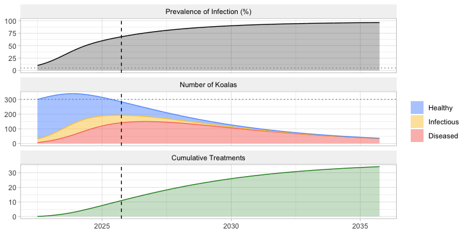

```r
baseline <- model$clone(deep=TRUE)
baseline$run(10, frequency=0)
baseline$autoplot() +
  geom_vline(xintercept=baseline$run_dates, lty="dashed")
```

### Testing interventions (phase 1)

For other scenarios, we split into 2 phases:

1. Phase 1: high-intensity sampling
2. Phase 2: lower-intensity sampling

For each of these we can use the assess_interventions function - for example:

```r
phase1 <- assess_interventions(
  model,
  years = 2,
  frequency = 1:4,
  prop_active = seq(0, 1, by=0.1),  # Change to by=0.01 for more precise results
  prop_targeted = 0.0
)

library("dplyr")
phase1 |>
  filter(Prevalence <= 5) |>
  group_by(Frequency) |>
  arrange(PropActive) |>
  slice(1L)
```

```
#> # A tibble: 3 × 5
#> # Groups:   Frequency [3]
#>   Frequency PropActive PropTargeted Prevalence Koalas
#>   <fct>          <dbl>        <dbl>      <dbl>  <dbl>
#> 1 2                0.8            0       3.66   182.
#> 2 3                0.6            0       4.26   177.
#> 3 4                0.5            0       3.77   174.
```

NOTE: these are rough numbers - change to by=0.01 for more precise results!

Then we can plot these results:

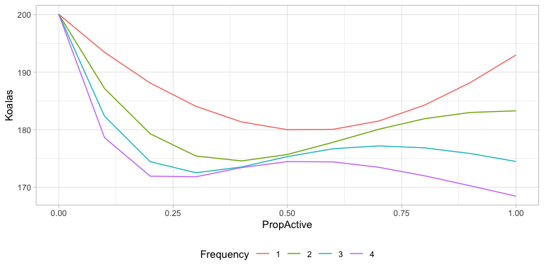

```r
phase1 |>
  ggplot(aes(x=PropActive, y=Koalas, col=Frequency)) +
  geom_line() +
  theme(legend.position="bottom")
```

Or we can look at the effect of targeted interventions alone:

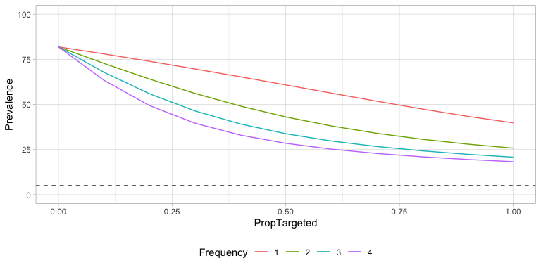

```r
phase1_targeted <- assess_interventions(
  model,
  years = 2,
  frequency = 1:4,
  prop_active = 0.0,
  prop_targeted = seq(0, 1, by=0.1)  # Change to by=0.01 for more precise results
)
phase1_targeted |>
  ggplot(aes(x=PropTargeted, y=Prevalence, col=Frequency)) +
  geom_line() +
  geom_hline(yintercept=5, lty="dashed") +
  theme(legend.position="bottom") +
  ylim(0,100)
```

Or we can look at a range of active proportions on top of targeted proportions fixed at 80%:

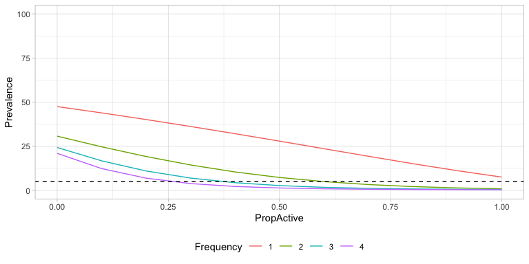

```r
phase1_both <- assess_interventions(
  model,
  years = 2,
  frequency = 1:4,
  prop_active = seq(0, 1, by=0.1),  # Change to by=0.01 for more precise results
  prop_targeted = 0.8
)
phase1_both |>
  ggplot(aes(x=PropActive, y=Prevalence, col=Frequency)) +
  geom_line() +
  geom_hline(yintercept=5, lty="dashed") +
  theme(legend.position="bottom") +
  ylim(0,100)
```

### Testing interventions (phase 2)

For phase 2, we first need to update the model using a phase 1 strategy e.g. a frequency of 4 and sampling proportion of 47% (the minimum required to get prevalence under 5% after 2 years):

```r
model$run(2, frequency = 4, prop_active = 0.47, prop_targeted = 0.0)
```

We can see that this does reduce the prevalence to less than 5%:

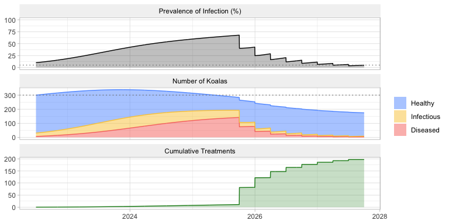

```r
model$autoplot()
```

Then we can assess phase 2 interventions using this as a starting point:

```r
phase2 <- assess_interventions(
  model,
  years = 8,
  frequency = 1:4,
  prop_active = seq(0, 1, by=0.1),  # Change to by=0.01 for more precise results
  prop_targeted = 0.0
)
phase2 |>
  filter(Prevalence <= 5) |>
  group_by(Frequency) |>
  arrange(PropActive) |>
  slice(1L)
```

```
#> # A tibble: 4 × 5
#> # Groups:   Frequency [4]
#>   Frequency PropActive PropTargeted Prevalence Koalas
#>   <fct>          <dbl>        <dbl>      <dbl>  <dbl>
#> 1 1                0.8            0      1.71    284.
#> 2 2                0.5            0      1.22    256.
#> 3 3                0.4            0      0.290   243.
#> 4 4                0.3            0      0.520   242.
```

NOTE: these are rough numbers - change to by=0.01 for more precise results!

Again, we can plot these results (a different graph is shown here):

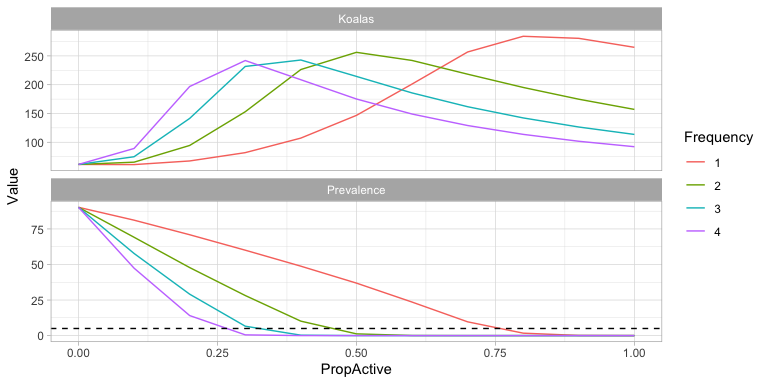

```r
library("tidyr")

phase2 |>
  pivot_longer("Prevalence":"Koalas", names_to="Metric", values_to="Value") |>
  ggplot(aes(x=PropActive, y=Value, col=Frequency)) +
  geom_line() +
  facet_wrap(~Metric, ncol=1, scales="free_y") +
  geom_hline(data=tibble(Metric="Prevalence", ll=5), mapping=aes(yintercept=ll), lty="dashed")
```

### Final scenario

Finally, we can update the model for 8 years with a frequency of 2 and proportion of 45% (the minimum required to keep the prevalence under 5%):

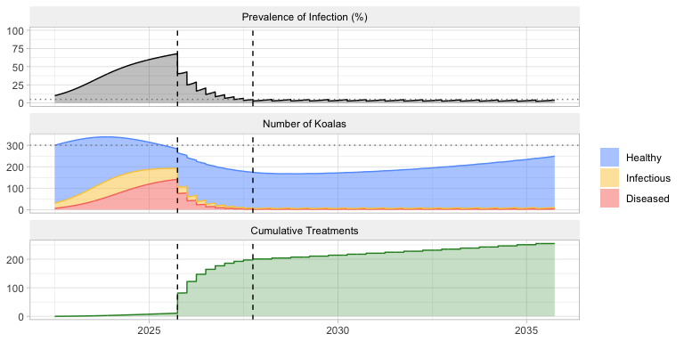

```r
model$run(8, frequency = 2, prop_active = 0.45)
model$autoplot() +
  geom_vline(xintercept=model$run_dates, lty="dashed")
```

## Creating a model object

The koalas model is designed as an encapsulated object, which is created as follows:

```r
library("koalas")
model <- KoalasV2$new()
```

This creates a model that you can then interrogate and manipulate using the active bindings and methods supplied. For example, we can set the initial state:

```r
model$set_state(S=299, I=1, R=0, Af=0, Cf=0)
```

And one or more parameters:

```r
model$set_parameters(birthrate=0.38)
```

For a complete list of valid state and parameter values see the help file for the class: ?KoalasV2

You can also see the current state and parameters using their active bindings:

```r
model$state |> simplify2array()
```

```
#>     S     V     I     N     R    Af    Cf    Sf    Vf    If    Nf    Rf   Day
#>   299     0     1     0     0     0     0     0     0     0     0     0     0
#> SumTx SumVx SumRx SumMx
#>     0     0     0     0
```

```r
model$parameters |> simplify2array()
```

```
#>           vacc_immune_duration          vacc_redshed_duration
#>                          1.000                          0.500
#>        natural_immune_duration                           beta
#>                          1.000                          2.750
#>            subcinical_duration subclinical_recover_proportion
#>                          0.500                          0.350
#>    diseased_recover_proportion                      birthrate
#>                          0.000                          0.380
#>                 acute_duration               lifespan_natural
#>                          0.400                          6.000
#>                 lifespan_acute               lifespan_chronic
#>                          4.000                          4.800
#>             relative_fecundity                    sensitivity
#>                          0.000                          0.950
#>                    specificity                    cure_prob_N
#>                          0.999                          0.900
#>                    cure_prob_I                    cure_prob_A
#>                          0.900                          0.750
#>                    cure_prob_C               vaccine_efficacy
#>                          0.600                          0.500
#>                vaccine_booster      passive_intervention_rate
#>                          0.500                          0.030
```

## Updating the model

To update the model for one or more day, use the update method with given number of days:

```r
model$update(21)
```

You can then extract the results so far as data frame:

```r
model$results_wide
```

```
#> # A tibble: 22 × 19
#>    Date         Day     S      V     I       N       R      Af       Cf       Sf
#>    <date>     <dbl> <dbl>  <dbl> <dbl>   <dbl>   <dbl>   <dbl>    <dbl>    <dbl>
#>  1 2022-01-01     0  299  0       1    0       0       0       0        0
#>  2 2022-01-02     1  299. 0.0123  1.01 7.47e-6 6.74e-5 4.75e-7 2.29e-14 0
#>  3 2022-01-03     2  299. 0.0246  1.01 1.50e-5 1.37e-4 3.76e-6 1.77e-12 1.79e-18
#>  4 2022-01-04     3  299. 0.0369  1.02 2.25e-5 2.09e-4 1.25e-5 2.13e-11 2.94e-17
#>  5 2022-01-05     4  300. 0.0491  1.02 3.01e-5 2.86e-4 2.93e-5 1.21e-10 2.20e-16
#>  6 2022-01-06     5  300. 0.0614  1.03 3.77e-5 3.70e-4 5.66e-5 4.64e-10 1.05e-15
#>  7 2022-01-07     6  300. 0.0736  1.04 4.53e-5 4.60e-4 9.67e-5 1.38e- 9 3.75e-15
#>  8 2022-01-08     7  300. 0.0858  1.04 5.30e-5 5.59e-4 1.52e-4 3.46e- 9 1.10e-14
#>  9 2022-01-09     8  300. 0.0981  1.05 6.07e-5 6.67e-4 2.24e-4 7.64e- 9 2.79e-14
#> 10 2022-01-10     9  300. 0.110   1.06 6.85e-5 7.86e-4 3.15e-4 1.53e- 8 6.33e-14
#> # ℹ 12 more rows
#> # ℹ 9 more variables: Vf <dbl>, If <dbl>, Nf <dbl>, Rf <dbl>, Z <dbl>,
#> #   SumTx <dbl>, SumVx <dbl>, SumRx <dbl>, SumMx <dbl>
```

When you want to apply an active intervention, use the active_intervention method with specified proportion of animals to test/treat/vaccinate:

```r
model$active_intervention(proportion=0.5)
```

You can then run for another period of time and re-extract results:

```r
model$update(21)
model$results_wide
```

```
#> # A tibble: 43 × 19
#>    Date         Day     S      V     I       N       R      Af       Cf       Sf
#>    <date>     <dbl> <dbl>  <dbl> <dbl>   <dbl>   <dbl>   <dbl>    <dbl>    <dbl>
#>  1 2022-01-01     0  299  0       1    0       0       0       0        0
#>  2 2022-01-02     1  299. 0.0123  1.01 7.47e-6 6.74e-5 4.75e-7 2.29e-14 0
#>  3 2022-01-03     2  299. 0.0246  1.01 1.50e-5 1.37e-4 3.76e-6 1.77e-12 1.79e-18
#>  4 2022-01-04     3  299. 0.0369  1.02 2.25e-5 2.09e-4 1.25e-5 2.13e-11 2.94e-17
#>  5 2022-01-05     4  300. 0.0491  1.02 3.01e-5 2.86e-4 2.93e-5 1.21e-10 2.20e-16
#>  6 2022-01-06     5  300. 0.0614  1.03 3.77e-5 3.70e-4 5.66e-5 4.64e-10 1.05e-15
#>  7 2022-01-07     6  300. 0.0736  1.04 4.53e-5 4.60e-4 9.67e-5 1.38e- 9 3.75e-15
#>  8 2022-01-08     7  300. 0.0858  1.04 5.30e-5 5.59e-4 1.52e-4 3.46e- 9 1.10e-14
#>  9 2022-01-09     8  300. 0.0981  1.05 6.07e-5 6.67e-4 2.24e-4 7.64e- 9 2.79e-14
#> 10 2022-01-10     9  300. 0.110   1.06 6.85e-5 7.86e-4 3.15e-4 1.53e- 8 6.33e-14
#> # ℹ 33 more rows
#> # ℹ 9 more variables: Vf <dbl>, If <dbl>, Nf <dbl>, Rf <dbl>, Z <dbl>,
#> #   SumTx <dbl>, SumVx <dbl>, SumRx <dbl>, SumMx <dbl>
```

Note that results are cumulative, i.e. you can keep updating the model and it will carry on from where it left off. This means you can apply interventions and/or change parameter values at whatever time points are required.

To re-set the model, create a new instance:

```r
model <- KoalasV2$new()
model$update(5)
model$results_wide
```

```
#> # A tibble: 6 × 19
#>   Date         Day     S      V     I     N     R    Af    Cf    Sf    Vf    If
#>   <date>     <dbl> <dbl>  <dbl> <dbl> <dbl> <dbl> <dbl> <dbl> <dbl> <dbl> <dbl>
#> 1 2022-01-01     0  300  0          0     0     0     0     0     0     0     0
#> 2 2022-01-02     1  300. 0.0123     0     0     0     0     0     0     0     0
#> 3 2022-01-03     2  300. 0.0247     0     0     0     0     0     0     0     0
#> 4 2022-01-04     3  300. 0.0370     0     0     0     0     0     0     0     0
#> 5 2022-01-05     4  301. 0.0493     0     0     0     0     0     0     0     0
#> 6 2022-01-06     5  301. 0.0616     0     0     0     0     0     0     0     0
#> # ℹ 7 more variables: Nf <dbl>, Rf <dbl>, Z <dbl>, SumTx <dbl>, SumVx <dbl>,
#> #   SumRx <dbl>, SumMx <dbl>
```

You can also extract aggregated results in a format more suitable for plotting:

```r
model$results_long
```

```
#> # A tibble: 36 × 4
#>    Date       Compartment Koalas Percent
#>    <date>     <fct>        <dbl>   <dbl>
#>  1 2022-01-01 Total         300      100
#>  2 2022-01-01 Healthy       300      100
#>  3 2022-01-01 Infectious      0        0
#>  4 2022-01-01 Diseased        0        0
#>  5 2022-01-01 Infertile       0        0
#>  6 2022-01-01 Immune          0        0
#>  7 2022-01-02 Total         300.     100
#>  8 2022-01-02 Healthy       300.     100
#>  9 2022-01-02 Infectious      0        0
#> 10 2022-01-02 Diseased        0        0
#> # ℹ 26 more rows
```

This produces the following (non-exclusive) combinations:

- Healthy = S+V+N+R
- Infectious = I+If+Af+Cf
- Diseased = Af+Cf
- Infertile = Sf+Vf+Nf+Rf+I+Af+Cf
- Immune = V+Vf+R+Rf+N+Nf